# Test simulation of children

Clare Horscroft

# Binary genotype

Set parameters

```r
set.seed(827441)

n<-100000
b<-0.2
```

Simulate parents' genotype and fitness.

```r
parents_geno<-sample(c(0,1),n,TRUE)
parents_fitness<-1+b*(rnorm(n,0,1)+parents_geno)
tapply(parents_fitness,parents_geno,mean)
```

```
##         0         1
## 0.9994265 1.2003996
```

This table shows that parents without the mutation on average have a fitness close to 1, and those with a copy of the mutation have an average fitness around 1.2 (1+b) as expected.

For each child choose two parents

```r
child_parent_1<-sample(1:n,n,replace=TRUE,prob=parents_fitness)
child_parent_2<-sample(1:n,n,replace=TRUE,prob=parents_fitness)
```

For each parent, count the number of children

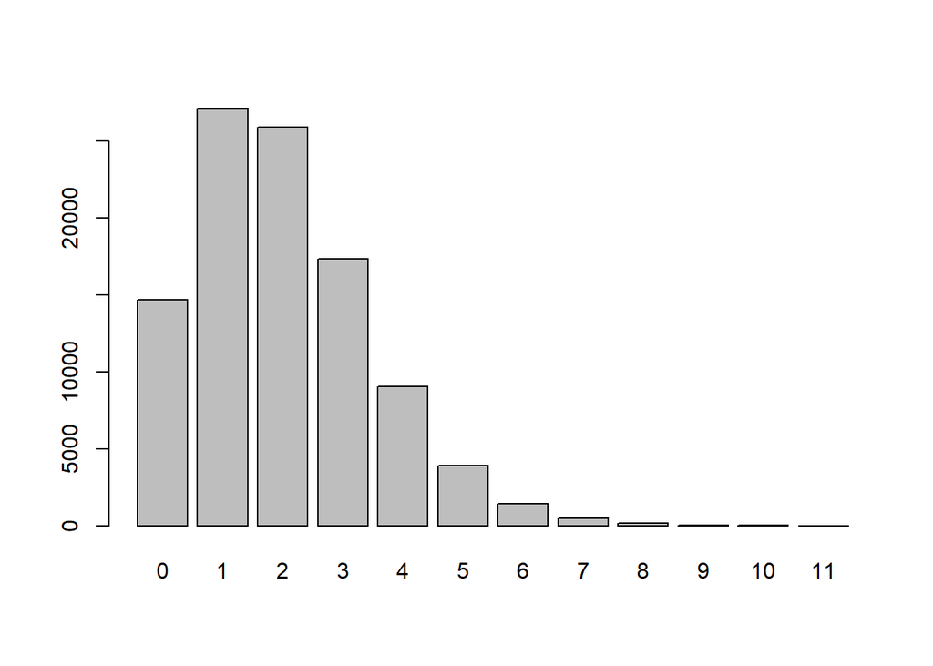

```r
parents_no_children<-rep(0,n)
tabParents<-table(c(child_parent_1,child_parent_2))
parents_no_children[as.numeric(unlist(dimnames(tabParents)))]<-tabParents
barplot(table(parents_no_children))
```

Mean number of childen by genotype

```r
mean_by_geno<-tapply(parents_no_children,parents_geno,mean)
mean_by_geno
```

```
##        0        1
## 1.823594 2.173183
```

Difference is

```r
unname(mean_by_geno[2]-mean_by_geno[1])
```

```
## [1] 0.3495897
```

geno = 1 divided by geno = 0 is

```r
unname(mean_by_geno[2]/mean_by_geno[1])
```

```
## [1] 1.191704
```

which is close to the fitness (1+b) as expected.

## Create models

```r
mod1<-lm(parents_no_children~parents_geno)
mod2<-glm(parents_no_children~parents_geno,family=poisson)
```

### linear model

```r
mod1
```

```
##
## Call:
## lm(formula = parents_no_children ~ parents_geno)
##
## Coefficients:
##  (Intercept)  parents_geno
##       1.8236        0.3496
```

Dividing the slope by the intercept recovers the selection coefficient (b)

```r
mod1$coefficients[2]/mod1$coefficients[1]
```

```
## parents_geno
##    0.1917037
```

### generalised linear model

```r
#intercept
glm_intercept<-exp(mod2$coefficients[[1]])
glm_intercept
```

```
## [1] 1.823594
```

```r
#slope
glm_slope<-exp(mod2$coefficients[[1]]) * (exp(mod2$coefficients[[2]]) - 1)
glm_slope
```

```
## [1] 0.3495897
```

Dividing the slope by the intercept recovers the selection coefficient (b)

```r
glm_slope/glm_intercept
```

```
## [1] 0.1917037
```

# Diploid genotype

Set parameters

```r
set.seed(827441)

n<-100000
b<-0.2
```

Simulate parents' genotype and fitness

```r
parents_geno<-sample(0:2,n,TRUE)
parents_fitness<-1+b*(rnorm(n,0,1)+parents_geno)
tapply(parents_fitness,parents_geno,mean)
```

```
##         0         1         2
## 0.9984528 1.1982867 1.4010518
```

This table shows that parents without the mutation on average have a fitness close to 1, and those with one copy of the mutation have an average fitness around 1.2 (1+b), and those with two copies have an average fitness of 1.4 (1+2b) as expected.

For each child choose two parents

```r
child_parent_1<-sample(1:n,n,replace=TRUE,prob=parents_fitness)
child_parent_2<-sample(1:n,n,replace=TRUE,prob=parents_fitness)
```

For each parent, count the number of children

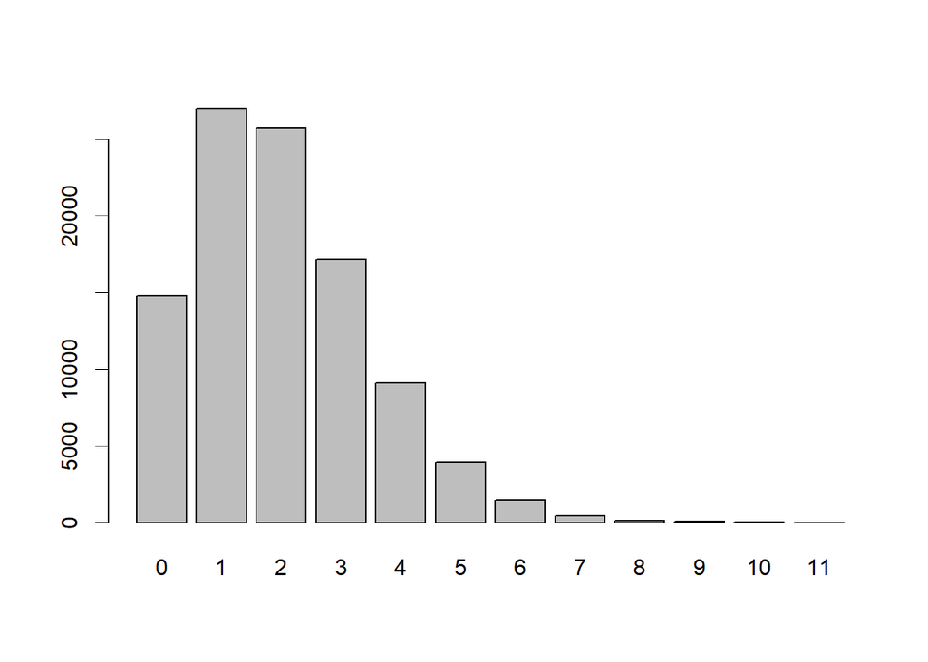

```r
parents_no_children<-rep(0,n)
tabParents<-table(c(child_parent_1,child_parent_2))
parents_no_children[as.numeric(unlist(dimnames(tabParents)))]<-tabParents
barplot(table(parents_no_children))
```

Mean number of childen by genotype

```r
mean_by_geno<-tapply(parents_no_children,parents_geno,mean)
mean_by_geno
```

```
##        0        1        2
## 1.665986 2.001215 2.336276
```

Difference is

```r
unname(c(mean_by_geno[2]-mean_by_geno[1],mean_by_geno[3]-mean_by_geno[2]))
```

```
## [1] 0.3352293 0.3350607
```

```r
unname(mean_by_geno[3]-mean_by_geno[1])
```

```
## [1] 0.6702901
```

Ratios are

```r
unname(c(mean_by_geno[2]/mean_by_geno[1],mean_by_geno[3]/mean_by_geno[2]))
```

```
## [1] 1.201220 1.167429
```

```r
unname(mean_by_geno[3]/mean_by_geno[1])
```

```
## [1] 1.402338
```

which is close to the fitness (1+b) as expected. Each mutations means a 0.2 higher proportion of children. People with two copies of the mutation have 1.4 times the amount of children on average than people with no mutations.

## Create models

```r
mod1<-lm(parents_no_children~parents_geno)
mod2<-glm(parents_no_children~parents_geno,family=poisson)
```

### linear model

```r
mod1
```

```
##
## Call:
## lm(formula = parents_no_children ~ parents_geno)
##
## Coefficients:
##  (Intercept)  parents_geno
##       1.6660        0.3351
```

Dividing the slope by the intercept recovers the selection coefficient (b)

```r
mod1$coefficients[2]/mod1$coefficients[1]
```

```
## parents_geno
##    0.2011658
```

### generalised linear model

```r
#intercept
glm_intercept<-exp(mod2$coefficients[[1]])
glm_intercept
```

```
## [1] 1.675456
```

```r
#slope
glm_slope<-exp(mod2$coefficients[[1]]) * (exp(mod2$coefficients[[2]]) - 1)
glm_slope
```

```
## [1] 0.3070578
```

```r
glm_slope/glm_intercept
```

```
## [1] 0.1832682
```